# Analysis On Mental Health In Fatal Police Shootings

By Caitlynn Li

## Introduction

In this tutorial, I would like to determine what the significant features of a victim in a fatal police shooting would be in order to determine whether or not they showed any signs of mental illness. I chose this dataset because it offers a lot of insight regarding all the fatal policing shootings from 2015 to 2021. Furthermore, mental health is a very important topic, especially in the midst of a pandemic, and can provide us with insights regarding police shootings. Mental illness controls more aspects of our lives than people would like to show, and this tutorial sets out to discover exactly what features have a significant relationship with mental illness. However, I think it is important to note that none of the records are of police brutality. To my knowledge, the shootings occurred because the victim posed as a serious threat to the safety of the police officers and others.

## Data Collection and Parsing

```python
#Import the necessary libraries
import pandas as pd
import numpy as np
import statsmodels.api as sm
import matplotlib.pyplot as plt
import datetime as dt
import seaborn as sns
from sklearn import datasets, linear_model
from sklearn.preprocessing import LabelEncoder
from sklearn.model_selection import train_test_split
from scipy.stats import chi2_contingency
```

### About The Data

Below, we are loading in the dataset. I got the dataset from the Washington Post, which you can access [here](https://github.com/washingtonpost/data-police-shootings). The data contains every fatal police shooting in the United States by a police officer in the line of duty since January 1, 2015. The data documents fatal shootings that occur when an on duty police officer shoots and kills a civilian. The dataset does not document the deaths of people in police custody, shootings from an off duty police officers, or non-shooting deaths.

These are the meanings behind each column, taken from the Washington Post [github](https://github.com/washingtonpost/data-police-shootings):

- id: a unique identifier for each victim
- name: the name of the victim
- date: the date of the fatal shooting in YYYY-MM-DD format
- manner_of_death: if they were just shot or shot and tasered
- armed: if the victim was carrying a weapon
  - undetermined: it is not known whether or not the victim had a weapon
  - unknown: the victim was armed, but it is not known what the object was
  - unarmed: the victim was not armed
- age: the age of the victim
- gender: the gender of the victim
- race:
  - W: White, non-Hispanic
  - B: Black, non-Hispanic
  - A: Asian
  - N: Indigenous
  - H: Hispanic
  - O: Other
  - None: unknown
- city: the municipality where the fatal shooting took place.
- state: two-letter postal code abbreviation
- signs of mental illness: News reports have indicated the victim had a history of mental health issues, expressed suicidal intentions or was experiencing mental distress at the time of the shooting.
- threat_level: The threat_level column was used to flag incidents for the story by Amy Brittain in October 2015. http://www.washingtonpost.com/sf/investigative/2015/10/24/on-duty-under-fire/ As described in the story, the general criteria for the attack label was that there was the most direct and immediate threat to life. That would include incidents where officers or others were shot at, threatened with a gun, attacked with other weapons or physical force, etc. The attack category is meant to flag the highest level of threat. The other and undetermined categories represent all remaining cases. Other includes many incidents where officers or others faced significant threats.
- flee: News reports have indicated the victim was moving away from officers
  - Foot
  - Car
  - Not fleeing
- body_camera: News reports have indicated an officer was wearing a body camera and it may have recorded some portion of the incident.
- latitude and longitude: the location of the shooting expressed as WGS84 coordinates, geocoded from addresses.
- is_geocoding_exact: reflects the accuracy of the coordinates.

```python
data = pd.read_csv('./fatal-police-shootings-data.csv')
data
```

|  | id | name | date | manner_of_death | armed | age | gender | race | city | state | signs_of_mental_illness | threat_level | flee | body_camera | longitude | latitude | is_geocoding_exact |
| --- | --- | --- | --- | --- | --- | --- | --- | --- | --- | --- | --- | --- | --- | --- | --- | --- | --- |
| 0 | 3 | Tim Elliot | 2015-01-02 | shot | gun | 53.0 | M | A | Shelton | WA | True | attack | Not fleeing | False | -123.122 | 47.247 | True |
| 1 | 4 | Lewis Lee Lembke | 2015-01-02 | shot | gun | 47.0 | M | W | Aloha | OR | False | attack | Not fleeing | False | -122.892 | 45.487 | True |
| 2 | 5 | John Paul Quintero | 2015-01-03 | shot and Tasered | unarmed | 23.0 | M | H | Wichita | KS | False | other | Not fleeing | False | -97.281 | 37.695 | True |
| 3 | 8 | Matthew Hoffman | 2015-01-04 | shot | toy weapon | 32.0 | M | W | San Francisco | CA | True | attack | Not fleeing | False | -122.422 | 37.763 | True |
| 4 | 9 | Michael Rodriguez | 2015-01-04 | shot | nail gun | 39.0 | M | H | Evans | CO | False | attack | Not fleeing | False | -104.692 | 40.384 | True |
| ... | ... | ... | ... | ... | ... | ... | ... | ... | ... | ... | ... | ... | ... | ... | ... | ... | ... |
| 6275 | 6845 | Felix Jerry Marquez | 2021-05-08 | shot | gun | 34.0 | M | NaN | Riverside | CA | False | attack | Not fleeing | False | -117.392 | 33.958 | True |
| 6276 | 6846 | Sagar Ghimire | 2021-05-08 | shot | gun | NaN | M | O | Baltimore | MD | True | attack | Not fleeing | False | NaN | NaN | True |
| 6277 | 6841 | Jeffrey Mark Murray | 2021-05-09 | shot | gun | 62.0 | M | NaN | Greenville | SC | False | attack | Not fleeing | False | NaN | NaN | True |
| 6278 | 6842 | NaN | 2021-05-09 | shot | gun | NaN | M | NaN | Lancaster | TX | False | attack | NaN | False | -96.806 | 32.604 | True |
| 6279 | 6844 | NaN | 2021-05-09 | shot | gun | NaN | M | W | Leicester | MA | False | attack | Not fleeing | False | -71.903 | 42.244 | True |

6280 rows × 17 columns

Below I am cleaning the data slightly and making the dataset more usable.

I decided to drop the city, longitude, latitude, and is_geocoding_exact columns because I wanted to simplify the dataset a little and generalized the location of the shooting the just the state. I thought keeping in the exact location of the shooting would overcomplicate my analysis as some were not accurate either.

```python
#Dropping data I did not think would be useful for my purposes.
data = data.drop(columns = ['name','id', 'city', 'longitude','latitude','is_geocoding_exact'])
```

```python
#If race is missing, replace it with unknown, so it will not be dropped
data['race'] = data['race'].fillna('Unknown')
```

```python
#Decided to drop all rows that had empty data because it did not result in significant data loss
data = data.dropna()
```

```python
#Converting the date to datetime to simplify further manipulations
data['date'] = pd.to_datetime(data['date'])
```

## Data Management and Representation

Here I am just visualizing the representation in the data. This is so we can better understand the basics of the dataset and what it represents.

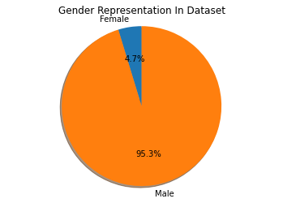

```python
#Making frequency table of gender
df = data.groupby('gender').size().reset_index(name = 'Freq')
labels = ['Female','Male']
sizes = df['Freq'].values

plt.pie(sizes, labels=labels, autopct='%1.1f%%',
        shadow=True, startangle=90)
plt.axis('equal')
plt.title('Gender Representation In Dataset')
plt.show()
```

As we can see above the significant majority of victims of fatal police shootings is male.

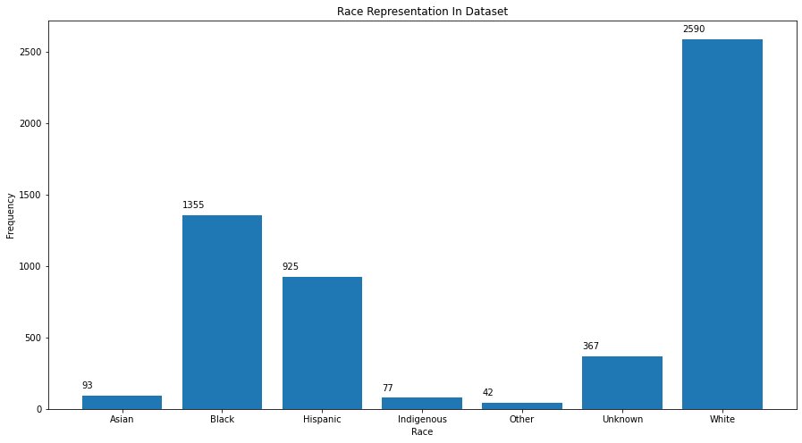

```python
#Frequency table of race
df = data.groupby('race').size().reset_index(name = 'Freq')
labels = np.sort(data['race'].unique().tolist())
sizes = df['Freq'].values
plt.figure(figsize=(15,8))
bars = plt.bar(['Asian', 'Black','Hispanic','Indigenous','Other','Unknown','White'],sizes)
plt.title('Race Representation In Dataset')
plt.xlabel("Race", fontsize = 10)
plt.ylabel("Frequency", fontsize = 10)

for bar in bars:
    yval = bar.get_height()
    plt.text(bar.get_x(), yval + 50, yval)
plt.show()
```

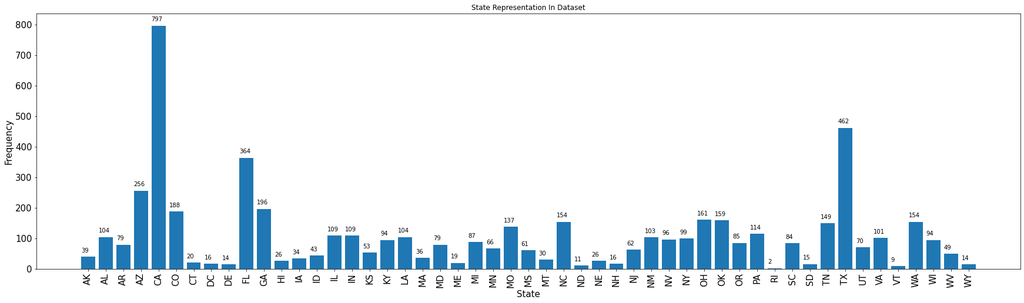

```python
#Frequency table of states
df = data.groupby('state').size().reset_index(name = 'Freq')
labels = np.sort(data['state'].unique().tolist())
sizes = df['Freq'].values
plt.figure(figsize=(30,8))
bars=plt.bar(labels,sizes)
plt.title('State Representation In Dataset')
plt.xlabel("State", fontsize = 15)
plt.ylabel("Frequency", fontsize = 15)
for bar in bars:
    yval = bar.get_height()
    plt.text(bar.get_x(), yval + 15, yval)
plt.xticks(rotation=90, fontsize = 15)
plt.yticks(fontsize = 15)
plt.show()
```

As we can see California has the most fatal police shootings compared to all other states, including D.C. However, this may be due to population. California is a highly populated state, so knowing that they have the most fatal police shootings is not too shocking or out of the ordinary.

# Exploratory Data Analysis

Here I will be looking more into the main features of the data and seeing if any trends arise.

```python
#Grouping by year
years = data['date'].dt.year.unique()
ages_per_year = [(data[data['date'].dt.year == year])['age'] for year in years]
```

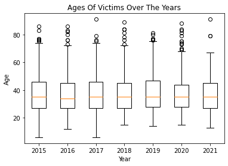

```python
plt.boxplot(ages_per_year,labels=years)
plt.xlabel("Year")
plt.ylabel("Age")
plt.title("Ages Of Victims Over The Years")
plt.show()
```

The ages of victims stay pretty consistent and evenly spread out over the years. This suggests that age has no impact on fatal police shootings. Though it does look like the data is skewed right. This may be because older citizens may be more susceptible to their injuries if they are shot compared to younger citizens.

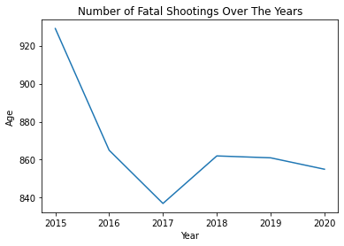

```python
#Plotting the number of fatal shootings over the years 2015 - 2020
#2021 is left out since the year has not finished so there will most likely be a significantly lower amount of fatal
#shootings
df = data.groupby(data.date.dt.year).size().reset_index(name = 'Freq')
df = df.drop(df.index[6])
plt.plot(df['date'],df['Freq'])
plt.xlabel("Year")
plt.ylabel("Age")
plt.title("Number of Fatal Shootings Over The Years")
plt.show()
```

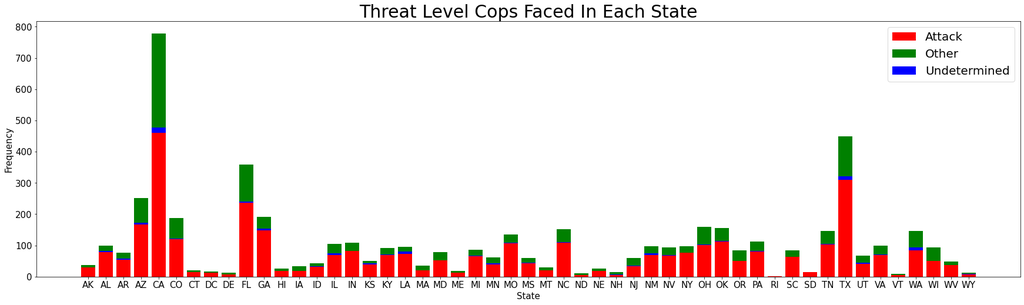

```python
#Plot the threat levels for each state
threat_levels = ['attack', 'other','undetermined']
states = np.sort(data['state'].unique().tolist())
freq = {}
all_freq = []
for t in threat_levels:
    for s in states:
        freq[s] = 0
    threat_level = np.array(data[data['threat_level'] == t]['state'])
    for i in threat_level:
        freq[i] = freq[i] + 1
    all_freq.append(list(freq.values()))

plt.figure(figsize=(30,8))
plt.bar(states,all_freq[0], color = 'r')
plt.bar(states,all_freq[1], bottom = all_freq[0], color = 'g')
plt.bar(states,all_freq[2], bottom = all_freq[0], color = 'b')
plt.title('Threat Level Cops Faced In Each State', fontsize = 30)
plt.xlabel("State", fontsize = 15)
plt.ylabel("Frequency", fontsize = 15)
plt.legend(["Attack", "Other", "Undetermined"], prop={'size': 20})
plt.xticks(fontsize = 15)
plt.yticks(fontsize = 15)
plt.show()
```

I wanted to see if there were any cops that pulled their weapon when there was no major threat. However, as we can see, very little police officers pulled their weapon when there was no threat to their safety or others.

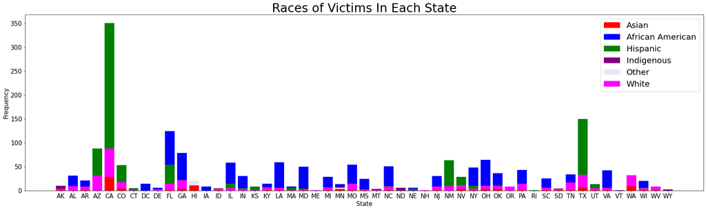

```python
#Composition of race in each state
races = np.sort(data['race'].unique().tolist())
states = np.sort(data['state'].unique().tolist())
freq = {}
all_freq = []
for r in races:
    for s in states:
        freq[s] = 0
    race = np.array(data[data['race'] == r]['state'])
    for i in race:
        freq[i] = freq[i] + 1
    all_freq.append(list(freq.values()))

plt.figure(figsize=(30,8))
plt.bar(states,all_freq[0], color = 'red')
plt.bar(states,all_freq[1], bottom = all_freq[0], color = 'blue')
plt.bar(states,all_freq[2], bottom = all_freq[0], color = 'green')
plt.bar(states,all_freq[3], bottom = all_freq[0], color = 'purple')
plt.bar(states,all_freq[4], bottom = all_freq[0], color = 'lavender')
plt.bar(states,all_freq[5], bottom = all_freq[0], color = 'fuchsia')
plt.title('Races of Victims In Each State', fontsize = 30)
plt.xlabel("State", fontsize = 15)
plt.ylabel("Frequency", fontsize = 15)
plt.legend(['Asian', 'African American', 'Hispanic','Indigenous','Other','White'], prop={'size': 20})
plt.xticks(fontsize = 15)
plt.yticks(fontsize = 15)
plt.show()
```

I wanted to see if there were any states that had an unproportionally large number of fatal shootings for a particular race. However, I think most of the states that have a rather large number of victims that were not white, also have a larger population of that particular race than others. For example, Maryland has a rather large number of African American victims. This, however, may be due to the fact that Baltimore has a high crime rate and a high African American population. It does not seem like there are any odd trends in the race of the victims.

```python
#Here I am trying to classify the weapons yielded from least to most dangerous. 1 being the least and 6 being the most
#They were classified at my discretion so the groupings should be seen as a general attempt at making the data more
#cohesive
def armed(x):
    if x == "unarmed":
        return 0
    elif x == "toy weapon":
        return 1
    elif "BB" in x or "pellet" in x or "bow" in x or "bean" in x or "nail" in x or "pistol" in x:
        return 3
    elif "sharp" in x or "axe" in x or "shard" in x or "pick" in x or "sword" in x or "spike" in x or "cut" in x or\
    "blade" in x or "cleaver" in x or "saw" in x or "fork" in x or "fork" in x or "bow" in x or "bayonet" in x:
        return 4
    elif "gun" in x:
        return 5
    elif "fireworks" in x or "explosive" in x or "grenade" in x:
        return 6
    else:
        return 2
```

```python
data["weapon_danger"] = data["armed"].apply(lambda x: armed(x))
```

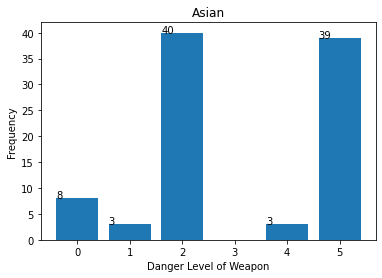

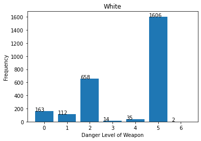

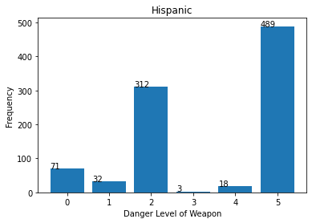

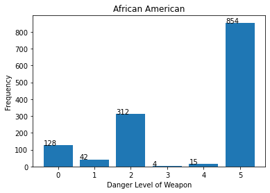

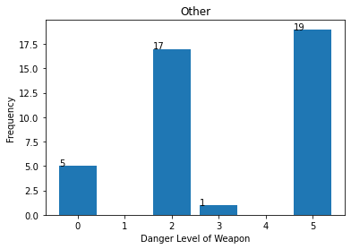

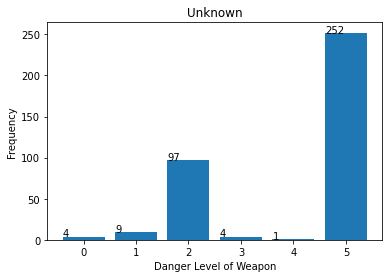

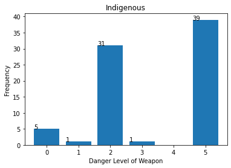

```python
#The weapons yielded by each race
df = data.groupby('state').size().reset_index(name = 'Freq')
races = (data['race'].unique())
label = ['Asian', 'White','Hispanic','African American','Other','Unknown','Indigenous']
i=0
for r in races:
    df = data[data['race'] == r]
    df = df.groupby('weapon_danger').size().reset_index(name = 'Freq')
    bars = plt.bar(df['weapon_danger'],df['Freq'])
    plt.title(label[i])

    plt.xlabel("Danger Level of Weapon", fontsize = 10)
    plt.ylabel("Frequency", fontsize = 10)
    for bar in bars:
        yval = bar.get_height()
        plt.text(bar.get_x(), yval, yval)
    plt.show()
    i=i+1
```

I wanted to see if there were any differences in the weapons yielded by each race. I wanted to see if there was any particular race that was fatally shot more when they were carrying a less lethal than when they were carrying a more dangerous weapon. As we can see most of the victims were shot when they were yielding a very dangerous weapon, by my classification they were yielding another gun. However, for Indigenous and Asian victims, a considerable proportion of them were not yielding very dangerous weapons, by my classification they were yielding miscellaneous and common household items that could be used as a weapon. The proportion of Indigenous and Asian victims that were fatally shot when yielding a less dangerous weapon is considerably larger than the other races. However, in this case I do not think this difference is caused by the lower number of victims for these races as a very dangerous weapon should be seen as more of a threat than a common household item regardless of race.

```python
#Split data into whether or not the victim showed signs of mental illness
mental_illness_true = data[data['signs_of_mental_illness'] == True]
mental_illness_false = data[data['signs_of_mental_illness'] == False]
```

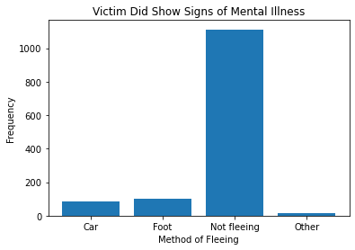

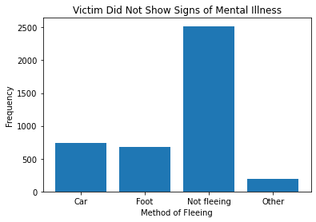

```python
#Plot frequencies of method of fleeing
df = mental_illness_true.groupby('flee').size().reset_index(name = 'Freq')
bars = plt.bar(df['flee'],df['Freq'])
plt.title('Victim Did Show Signs of Mental Illness')
plt.xlabel("Method of Fleeing", fontsize = 10)
plt.ylabel("Frequency", fontsize = 10)
plt.show()

df = mental_illness_false.groupby('flee').size().reset_index(name = 'Freq')
bars = plt.bar(df['flee'],df['Freq'])
plt.title('Victim Did Not Show Signs of Mental Illness')
plt.xlabel("Method of Fleeing", fontsize = 10)
plt.ylabel("Frequency", fontsize = 10)
plt.show()
```

As we can see above, there is a significant difference in the proportion of victims with signs of mental illness that fled compared to the proportion of victims with no signs of mental illness that fled. Whether or not a victim showed signs of mental illness has an influence of whether or not they fled. This makes me wonder if there are other factors that one's mental state has control over. This is interesting and is something that we are able to further investigate.

## Hypothesis Testing and Machine Learning

I decided to perform feature selection using the Chi Square Test. The Chi Square test of independence tells us if there's is a significant relationship between two categorical variables. Since the majority of my data was categorical, I decided this was a suitable method. I want to determine the significant features in predicting whether a victim showed signs of a mental illness or not. The Chi Square test of independence is also very suitable for feature selecting as it will tell us which variables have a significant relationship. When performing our chi squared test, we will be testing the following hypotheses:

**Null Hypothesis:** There is no relationship between the two variables.  
**Alternative Hypothesis:** There is a relationship between the two variables.

```python
#Turning integer data into object, so it can later be used as a categorical variable
data['age'] = data['age'].astype('object')
data['date'] = data['date'].astype('object')
categorical_vars = data.select_dtypes(exclude = 'number').drop('signs_of_mental_illness', axis = 1).columns
```

```python
categorical_vars
```

```
Index(['date', 'manner_of_death', 'armed', 'age', 'gender', 'race', 'state',
       'threat_level', 'flee', 'body_camera'],
      dtype='object')
```

```python
#Here we are performing the chi square test between our target variable signs_of_mental_illness, and all categorical variables, using a p-value of .05
chi2_check = []
for i in categorical_vars:
    if chi2_contingency(pd.crosstab(data['signs_of_mental_illness'], data[i]))[1] < 0.05:
        chi2_check.append('Reject Null Hypothesis')
    else:
        chi2_check.append('Fail to Reject Null Hypothesis')
res = pd.DataFrame(data = [categorical_vars, chi2_check]
             ).T
res.columns = ['Column', 'Hypothesis']
print(res)
```

```
            Column                      Hypothesis
0             date  Fail to Reject Null Hypothesis
1  manner_of_death          Reject Null Hypothesis
2            armed          Reject Null Hypothesis
3              age          Reject Null Hypothesis
4           gender          Reject Null Hypothesis
5             race          Reject Null Hypothesis
6            state          Reject Null Hypothesis
7     threat_level          Reject Null Hypothesis
8             flee          Reject Null Hypothesis
9      body_camera          Reject Null Hypothesis
```

As we can see from our table, we are able to reject the null hypothesis for all variables except date. indicating there is a significant relationship between signs_of_mental_illness and those variables.

However, since we have multiple classes within each categorical variable, we are unable to determine exactly which class is responsible for the relationship. In order to effectively determine exactly which feature is responsible, we need to perform a OneHotEncoding. A OneHotEncoding will simply tell us if a feature is present or not in a particular observation. By doing this we will be able to pinpoint exactly which feature is responsible.

It is also important to note that comparing multiple classes against each other will compound the error rate of a false positive. This means that if we start off with a p-value of .05, there is a 5% chance of a false positive at the first class. However, as we go on to evaluate the next class, the error rate of a false positive will become 10%. In order to combat this, we will use the **Bonferroni-adjusted method**. This is where the p-value becomes the original p-value divided by the number of classes for each categorical variable.

```python
check = {}
#Performing OneHotEncoding on the variables that displayed a significant relationship with signs_of_mental_illness
for i in res[res['Hypothesis'] == 'Reject Null Hypothesis']['Column']:
    #Creating the onehotencoding columns
    dummies = pd.get_dummies(data[i])
    #calculating adjusted p-value
    bon_p_value = 0.05/data[i].nunique()

    #Performing chi square test of independence for each class
    for series in dummies:
        if chi2_contingency(pd.crosstab(data['signs_of_mental_illness'], dummies[series]))[1] < bon_p_value:
            check['{}-{}'.format(i, series)] = 'Reject Null Hypothesis'
        else:
            check['{}-{}'.format(i, series)] = 'Fail to Reject Null Hypothesis'
res_chi_ph = pd.DataFrame(data = [check.keys(), check.values()]).T
res_chi_ph.columns = ['Pair', 'Hypothesis']
```

```python
res_chi_ph
```

|  | Pair | Hypothesis |
| --- | --- | --- |
| 0 | manner_of_death-shot | Reject Null Hypothesis |
| 1 | manner_of_death-shot and Tasered | Reject Null Hypothesis |
| 2 | armed-Airsoft pistol | Fail to Reject Null Hypothesis |
| 3 | armed-BB gun | Fail to Reject Null Hypothesis |
| 4 | armed-BB gun and vehicle | Fail to Reject Null Hypothesis |
| ... | ... | ... |
| 242 | flee-Foot | Reject Null Hypothesis |
| 243 | flee-Not fleeing | Reject Null Hypothesis |
| 244 | flee-Other | Reject Null Hypothesis |
| 245 | body_camera-False | Reject Null Hypothesis |
| 246 | body_camera-True | Reject Null Hypothesis |

247 rows × 2 columns

As we can see, we are now seeing if there is a relationship between 247 variables, compared to our original 10 variables.

```python
data_log = pd.get_dummies(data = data, columns = categorical_vars,\
                          drop_first =True)
```

Now that we have performed our feature selection, and determined which features have a significant impact on signs_of_mental_illness, we want to see how our selected features will impact our prediction model. Since we want to see which features a victim's mental state may have influence over, we should be able to predict a victim's mental state given the variables that are signifiacantly related to the victim's mental state. The model with the significant features should be more accurate than the model with all features as it only focuses on the influential features.

```python
#Turning target variable into numerical value
data_log['signs_of_mental_illness'] = data_log['signs_of_mental_illness'].apply(lambda x: 0 if x == False else 1)
```

```python
#Splitting our data into train and test set
X_train, X_test, y_train, y_test = train_test_split(data_log.drop('signs_of_mental_illness', axis =1),\
                                                    data_log['signs_of_mental_illness'], test_size = 0.30,\
                                                    random_state = 101)
```

```python
#Creating the prediction model using all of data, not just the ones we determined were significant
from sklearn.linear_model import LogisticRegression
log_model = LogisticRegression(max_iter = 1000)
log_model.fit(X_train, y_train)
#Performance Check
from sklearn.metrics import classification_report, confusion_matrix, roc_curve,auc, accuracy_score
predictions = log_model.predict(X_test)
print(accuracy_score(y_test, predictions))
```

```
0.7541284403669725
```

```python
print(classification_report(y_test,predictions))
```

```
              precision    recall  f1-score   support

           0       0.78      0.95      0.85      1235
           1       0.49      0.15      0.23       400

    accuracy                           0.75      1635
   macro avg       0.63      0.55      0.54      1635
weighted avg       0.71      0.75      0.70      1635
```

As we can see from our classification report, we are much more accurate in predicting if a victim does not show signs of mental illness, than if they did show signs of mental illness. However, we also have more victims that did not show signs of mental illness than those who did, which may play a role in why we are more accurate predicting if they did not show signs of mental illness.

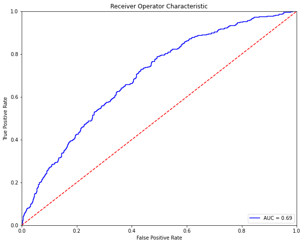

```python
#Creating the ROC-AUC plot
preds = log_model.predict_proba(X_test)[:,1]
fpr, tpr, threshold = roc_curve(y_test, preds)
roc_auc = auc(fpr, tpr)
plt.figure(figsize=(10,8))
plt.title('Receiver Operator Characteristic')
plt.plot(fpr, tpr, 'b', label = 'AUC = {}'.format(round(roc_auc, 2)))
plt.legend(loc = 'lower right')
plt.plot([0,1], [0,1], 'r--')
plt.xlim([0,1])
plt.ylim([0,1])
plt.ylabel('True Positive Rate')
plt.xlabel('False Positive Rate')
plt.show()
```

Our AUC-ROC plot helps us visualize how well our model is at distinguishing between classes. The higher the AUC is, the better the model is at distinguishing if a victim showed signs of a mental illness or not. As we can see from our plot, our model currently has an AUC of .69, meaning there is a 69% chance we are able to distinguish between the two classes of our target variable.

Now we will create the prediction model only using the significant features.

```python
#Get the list of all the significant pairwise
significant_chi = []
for i in res_chi_ph[res_chi_ph['Hypothesis'] == 'Reject Null Hypothesis']['Pair']:
    significant_chi.append('{}_{}'.format(i.split('-')[0],i.split('-')[1]))

#Drop the data with reduntant information. For example, we already know if a victim was female, if they were not male.
for i in ['gender_F', 'manner_of_death_shot', 'flee_Car','threat_level_attack','body_camera_False']:
    significant_chi.remove(i)
print(significant_chi)
```

[output not shown]

```python
log_model = LogisticRegression(max_iter = 1000)
log_model.fit(X_train[significant_chi], y_train)
#Metrics check
predictions = log_model.predict(X_test[significant_chi])
print(accuracy_score(y_test, predictions))
```

```
0.7608562691131499
```

```python
print(classification_report(y_test,predictions))
```

```
              precision    recall  f1-score   support

           0       0.77      0.98      0.86      1235
           1       0.57      0.10      0.17       400

    accuracy                           0.76      1635
   macro avg       0.67      0.54      0.51      1635
weighted avg       0.72      0.76      0.69      1635
```

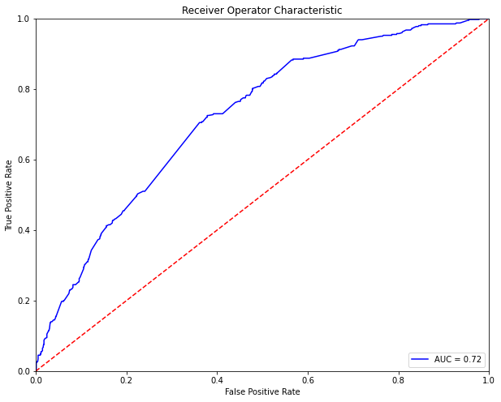

```python
#Creating the AUC-ROC plot using our model with only the significant features
preds = log_model.predict_proba(X_test[significant_chi])[:,1]
fpr, tpr, threshold = roc_curve(y_test, preds)
roc_auc = auc(fpr, tpr)
plt.figure(figsize=(10,8))
plt.title('Receiver Operator Characteristic')
plt.plot(fpr, tpr, 'b', label = 'AUC = {}'.format(round(roc_auc, 2)))
plt.legend(loc = 'lower right')
plt.plot([0,1], [0,1], 'r--')
plt.xlim([0,1])
plt.ylim([0,1])
plt.ylabel('True Positive Rate')
plt.xlabel('False Positive Rate')
plt.show()
```

As we can see our AUC did improve, though not by much. It still tells us that our model is more accurate when using our selected features.

Here is a good [tutorial](https://towardsdatascience.com/categorical-feature-selection-via-chi-square-fc558b09de43) that helped me a lot and offers a lot of insight on feature selection.

## Conclusion

In this tutorial we wanted to see which characteristics of victims to fatal police shootings could be attributed to their mental state. In the exploratory data analysis section of our tutorial, we played around with the data to see if there were any trends or hypotheses we could from about our data. During this step, we discovered that the victim's mental state seemed to have played a role in whether or not they decided to flee. This prompted us to ask the question: **What other features may have been influenced by the victim's mental state?** In our machine learning section, we used the chi square test of independence to determine exactly which characteristics of a fatal police shooting is related to the victim's mental state. At the end we were able to determine that the victim's manner of death, age, weapon yielded, whether or not they fled, among other variables all maintained a significant relationship with the victim's mental state. We found that by only using these variables to predict the victim's mental state, we were able to obtain a higher rate of success compared to when we used all variables in our prediction model.

## Resources

These were all the resources I used to help me in this project and resources you can use to learn more about the skills used and topic discussed:

- [Feature Selection Using Chi Square](https://towardsdatascience.com/categorical-feature-selection-via-chi-square-fc558b09de43)
- [Understanting The AUC-ROC plot](https://towardsdatascience.com/understanding-auc-roc-curve-68b2303cc9c5)
- [What Causes Mental Health](https://www.mind.org.uk/information-support/types-of-mental-health-problems/mental-health-problems-introduction/causes/)
- [Mental Health and Criminal Justice](https://www.prisonpolicy.org/research/mental_health/)
- [Dataset](https://github.com/washingtonpost/data-police-shootings)